# IODS course project

Lashini Liyanage

# Introduction to Open Data Science - Course Project

## About the course

*Write a short description about the course and add a link to your GitHub repository here. This is an R Markdown (.Rmd) file so you should use R Markdown syntax.*

```r
# This is a so-called "R chunk" where you can write R code.

date()
```

```
## [1] "Fri Nov 18 22:59:55 2022"
```

I am excited to participate in this course and learn more about R. When I first arrived in Finland two months ago, my R knowledge was elementary. However, after taking QRS skills, I learned many things. I want to improve my skills in R through this course.I look forward to analyzing longitudinal data and the clustering & classification parts the most. Working with GitHub will be a new experience for me. When I first saw this course through the courses guide, I wanted to do this as one of my future goals is to do a doctoral degree, and this course would be a perfect course for that. As I already had experience with the “R for Health Data Science” book, I could quickly go through Exercise Set 1. On the other hand, I feel overwhelmed to be a teacher assistant in this course. So I can help other students and, at the same time, I can improve my knowledge. I look forward to the upcoming journey.

## Link

https://github.com/LashiniLiyanage/IODS-project

# Regression Analysis

*Describe the work you have done this week and summarize your learning.*

- I worked on data wrangling, graphical representation and linear regression during this week.

```r
date()
```

```
## [1] "Fri Nov 18 22:59:55 2022"
```

## Read the data

```r
data <- read.table("https://raw.githubusercontent.com/KimmoVehkalahti/Helsinki-Open-Data-Science/master/datasets/learning2014.txt", sep=",", header=TRUE)

dim(data)
```

```
## [1] 166   7
```

```r
str(data)
```

```
## 'data.frame':    166 obs. of  7 variables:
##  $ gender  : chr  "F" "M" "F" "M" ...
##  $ age     : int  53 55 49 53 49 38 50 37 37 42 ...
##  $ attitude: num  3.7 3.1 2.5 3.5 3.7 3.8 3.5 2.9 3.8 2.1 ...
##  $ deep    : num  3.58 2.92 3.5 3.5 3.67 ...
##  $ stra    : num  3.38 2.75 3.62 3.12 3.62 ...
##  $ surf    : num  2.58 3.17 2.25 2.25 2.83 ...
##  $ points  : int  25 12 24 10 22 21 21 31 24 26 ...
```

Even though, I have successfully wrangled the dataset, I decided to go with Kimmo’s analyzed dataset for further analysis.

I gave the dataset a name as “data”. In the further analysis, this dataset willbe adressed by “data”.

Before the wrangling, there were 183 observations and 60 variables. For this analysis, we have excluded those who have obtained 0 for Exam Points. So the observation count for this dataset is 166. Even though there were 60 variables in the main dataset, we have selected only 7 variables for this: gender, age, attitude, deep (deep learning), stra (strategic learning), surf (surface learning) and points (exam points).The variables gender, age and points were directly used in the analysis. The “attitude” variable was created using “Attitude/10” from the previous dataset. The variable “surf” was created using the mean value of questions related surface questions. The variable “stra” was created using the mean value of questions related strategic questions. The variable “deep” was created using the mean value of questions related deep questions. Gender is the only character variable, while all the other are numerical variables. Out of them age and points variables are integers. Thus this dataset consist of 166 observations and 7 variables.

## Graphical Overview and the Summary of data

### Descriptive Statistics

```r
summary(data)
```

```
##     gender               age           attitude          deep
##  Length:166         Min.   :17.00   Min.   :1.400   Min.   :1.583
##  Class :character   1st Qu.:21.00   1st Qu.:2.600   1st Qu.:3.333
##  Mode  :character   Median :22.00   Median :3.200   Median :3.667
##                     Mean   :25.51   Mean   :3.143   Mean   :3.680
##                     3rd Qu.:27.00   3rd Qu.:3.700   3rd Qu.:4.083
##                     Max.   :55.00   Max.   :5.000   Max.   :4.917
##       stra            surf           points
##  Min.   :1.250   Min.   :1.583   Min.   : 7.00
##  1st Qu.:2.625   1st Qu.:2.417   1st Qu.:19.00
##  Median :3.188   Median :2.833   Median :23.00
##  Mean   :3.121   Mean   :2.787   Mean   :22.72
##  3rd Qu.:3.625   3rd Qu.:3.167   3rd Qu.:27.75
##  Max.   :5.000   Max.   :4.333   Max.   :33.00
```

Gender : This is a categorical variable, So it is not possible to compute descriptive statistics.

Age: The youngest participant is 17 years old while the oldest participant is 55 years old. The average age of the study participants is 25.51 (~26) years. Attitude: The values of attitude ranges from 1.40 to 5.00. The average of attitude is 3.14 while the median is 3.20. Deep Learning : The values of deep ranges from 1.59 to 4.92. The average of deep is 3.68 while the median is 3.67. Strategic Learning : The values of stra ranges from 1.25 to 5.00. The average of stra is 3.12 while the median is 3.19. Surface Learning: The values of surf ranges from 1.58 to 4.33. The average of surf is 2.79 while the median is 2.83. Exam Points: The lowest exam point is 7 while the highest exam point is 33 The average exam points is 22.72 (~23) and the median is 23.

### Graphical overview of the data

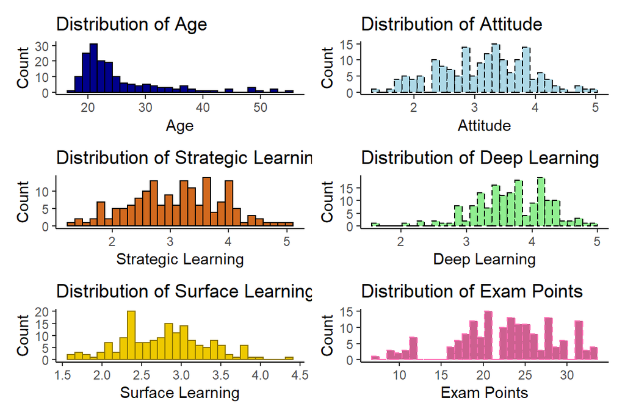

```r
data <- read.table("https://raw.githubusercontent.com/KimmoVehkalahti/Helsinki-Open-Data-Science/master/datasets/learning2014.txt", sep=",", header=TRUE)

library(ggplot2)
library(patchwork)

# Distribution of Age
a <- ggplot(data, aes(x = age))+
  geom_histogram(color = "black", fill = "darkblue", bins = 30) +
  labs(title="Distribution of Age",x="Age", y = "Count") +
  theme_classic()

# Distribution of Attitude
b <- ggplot(data, aes(x = attitude))+
  geom_histogram(color="black", fill="lightblue",linetype="dashed", bins = 30) +
  labs(title="Distribution of Attitude",x="Attitude", y = "Count") +
  theme_classic()

# Distribution of Strategic Learning
c <- ggplot(data, aes(x = stra))+
  geom_histogram(color = "black", fill = "chocolate", bins = 30) +
  labs(title="Distribution of Strategic Learning",x="Strategic Learning", y = "Count") +
  theme_classic()

# Distribution of Deep Learning
d <- ggplot(data, aes(x = deep))+
  geom_histogram(color="black", fill="lightgreen",linetype="dashed", bins = 30) +
  labs(title="Distribution of Deep Learning",x="Deep Learning", y = "Count") +
  theme_classic()

# Distribution of Surface Learning
e <- ggplot(data, aes(x = surf))+
  geom_histogram(color="gold4", fill="gold2", bins = 30) +
  labs(title="Distribution of Surface Learning",x="Surface Learning", y = "Count") +
  theme_classic()

# Distribution of Exam Points
f <- ggplot(data, aes(x = points))+
  geom_histogram(color="hotpink1", fill="hotpink3",linetype="dashed", bins = 30) +
  labs(title="Distribution of Exam Points",x="Exam Points", y = "Count") +
  theme_classic()

(a + b) / (c+d) /(e+f)
```

Through these histograms, we can see that age lies on a positively skewed distribution. Deep learning shows a lit bit of a negatively skewed distribution. Distribution of attitude and the distribution of the strategic learning shows normal yet multi-mode distribution. The distribution of surface learning lies on slightly positive skewed distribution. The distribution of exam points is not clearly visible.

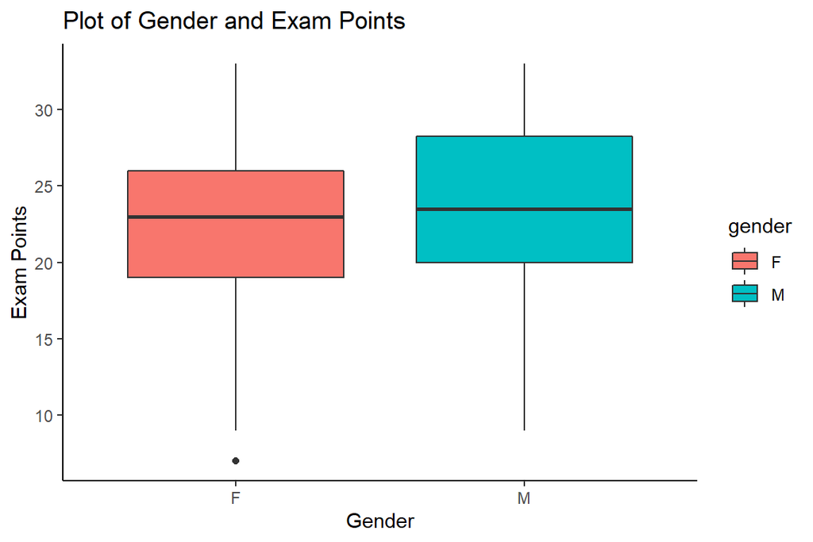

```r
# Gender and Exam Points

p1 <- ggplot(data, aes(x = gender, y = points, fill = gender)) +
  labs(title="Plot of Gender and Exam Points",x="Gender", y = "Exam Points") +
  theme_classic()

p2 <- p1 + geom_boxplot()
p2
```

The median exam points of both males and females are quite similar to each other. But the female exam points are left skewed while the male exam points are right skewed. There is one outlier in the female category.

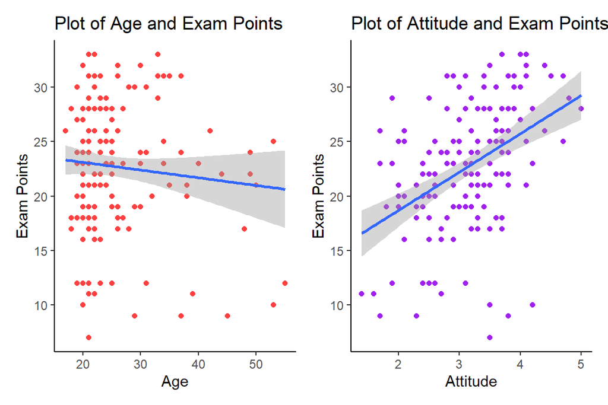

```r
# Age and Exam Points

a1 <- ggplot(data, aes(x = age, y = points)) +
  labs(title="Plot of Age and Exam Points",x="Age", y = "Exam Points")
a <- a1 + geom_point(colour = "brown1") + theme_classic() + geom_smooth(method = "lm")


# Attitude and Exam Points

b1 <- ggplot(data, aes(x = attitude, y = points)) +
  labs(title="Plot of Attitude and Exam Points",x="Attitude", y = "Exam Points")
b <- b1 + geom_point(colour = "purple") + theme_classic() + geom_smooth(method = "lm")

a + b
```

It is clear to see that there is a positive relationship between attitude and the exam points. There is no any clear linear relationship between age and the exam points. However, the regression line shows that there is a negative linear relationship between age and the exam points.

[figure not shown]

```r
# Strategic Learning and Exam Points

c1 <- ggplot(data, aes(x = stra,  y = points)) +
  labs(title="Plot of Attitude and Exam Points",x="Strategic Learning", y = "Exam Points")
c <- c1 + geom_point(colour = "orange") + theme_classic() + geom_smooth(method = "lm")


# Deep Learning and Exam Points

d1 <- ggplot(data, aes(x = deep, y = points)) +
  labs(title="Plot of Deep Learning and Exam Points",x="Deep Learning", y = "Exam Points")
d <- d1 + geom_point(colour = "aquamarine3") + theme_classic() + geom_smooth(method = "lm")


# Surface Learning and Exam Points

e1 <- ggplot(data, aes(x = surf, y = points)) +
  labs(title="Plot of Surface Learning and Exam Points",x="Surface Learning", y = "Exam Points")
e <- e1 + geom_point(colour = "chartreuse") + theme_classic() + geom_smooth(method = "lm")

c+d/e
```

There is a weak positive linear relationship between strategic learning and the exam points. There is no any clear linear relationship between deep learning and the exam points. However, the regression line shows that there is a weak negative linear relationship between deep learning nd exam points. There is a weak negative linear relationship between surface learning and the exam points.

## Model Fitting and Interpretation

```r
# Model 1

Model1 <- lm(points ~ attitude + stra + deep, data = data)
summary(Model1)
```

```
##
## Call:
## lm(formula = points ~ attitude + stra + deep, data = data)
##
## Residuals:
##      Min       1Q   Median       3Q      Max
## -17.5239  -3.4276   0.5474   3.8220  11.5112
##
## Coefficients:
##             Estimate Std. Error t value Pr(>|t|)
## (Intercept)  11.3915     3.4077   3.343  0.00103 **
## attitude      3.5254     0.5683   6.203 4.44e-09 ***
## stra          0.9621     0.5367   1.793  0.07489 .
## deep         -0.7492     0.7507  -0.998  0.31974
## ---
## Signif. codes:  0 '***' 0.001 '**' 0.01 '*' 0.05 '.' 0.1 ' ' 1
##
## Residual standard error: 5.289 on 162 degrees of freedom
## Multiple R-squared:  0.2097, Adjusted R-squared:  0.195
## F-statistic: 14.33 on 3 and 162 DF,  p-value: 2.521e-08
```

Call:

Here it shows our explanatory variables: “attitude”, “strategic learning (stra)” and “Deep learning (deep)” and the dependent variable:“exam points (points).

Residuals:

The residuals are the difference between the actual values and the predicted values. It is good to see that the median value is near to zero (0.5474), as this would tell us our residuals are somewhat symmetrical and that our model is predicting evenly at both the high and low ends of our dataset. Even though this dataset is slightly left-skewed, it is almost shows a normal distribution.

Coefficients:

Regarding the estimates, Y = 11.3915 + 3.5254(x1) + 0.9621(x2) - 0.7492(x3) Here x1 means the attitude, x2 means the strategic learning and the x3 means deep learning.

Even without any of the attitude, strategic learning and deep learning, the students would score 11.39 points for the exam.Then, for one additional unit of attitude, the exam points will increase by 3.53 (when strategic learning and deep learning is constant). For one additional unit of strategic learning, the exam points will increase only by 0.96 (when attitude and deep learning is constant). For one additional unit of deep learning, the exam points will decrease by 0.75 (when strategic learning and attitude is constant).

Regarding the standard error, This shows the standard deviation of the coefficient. Through this we can get an idea about the uncertainty of the coefficient. The standard error is used to create confidence intervals.

Looking at the confidence interval, it is clear with 95% confident that the actual slope (attitude) is between (3.5254 ± 1.96(0.5683)) = 2.41 and 4.64. Looking at the confidence interval, it is clear with 95% confident that the actual slope (strategic learning) is between (0.9621 ± 1.96(0.5367)) = -0.09 and 2.01. Looking at the confidence interval, it is clear with 95% confident that the actual slope (deep learning) is between (-0.7492 ± 1.96(0.7507)) = -2.22 and 0.722.

Regarding the t-value, It is the value of coefficient divided by the standard error. It is always better to large t-statistics, because it indicates that the standard error is small in comparison to the coefficient. Compared to the strategic learning and the deep learning, the t value of attitude is far from 0, indicating that the coefficient is not zero.

Regarding the Pr(>|t|), This is calculated using the t-statistic from the T distribution, to understand how significant the coefficient is to the model. In general p < 0.05, is believed to be significant: the coefficient add value to the model by helping to explain the variance within the dependent variable. In this model, it is showed that only the “attitude” variable is significant under 0.05. The “strategic learning (stra)” and the “deep learning (deep)” is not significant under 0.05.

Thus, I decided to drop both the variables: stra and deep to further analysis purpose.

```r
# Model 2

Model2 <- lm(points ~ attitude , data = data)
summary(Model2)
```

```
##
## Call:
## lm(formula = points ~ attitude, data = data)
##
## Residuals:
##      Min       1Q   Median       3Q      Max
## -16.9763  -3.2119   0.4339   4.1534  10.6645
##
## Coefficients:
##             Estimate Std. Error t value Pr(>|t|)
## (Intercept)  11.6372     1.8303   6.358 1.95e-09 ***
## attitude      3.5255     0.5674   6.214 4.12e-09 ***
## ---
## Signif. codes:  0 '***' 0.001 '**' 0.01 '*' 0.05 '.' 0.1 ' ' 1
##
## Residual standard error: 5.32 on 164 degrees of freedom
## Multiple R-squared:  0.1906, Adjusted R-squared:  0.1856
## F-statistic: 38.61 on 1 and 164 DF,  p-value: 4.119e-09
```

Call:

Here it shows our explanatory variables: “attitude” and the dependent variable:“exam points (points).

Residuals:

As the median value is near to zero (0.4339), the residuals are somewhat symmetrical. This model predicts evenly at both the high and low ends of the dataset. Even though this dataset is slightly left-skewed, it is almost shows a normal distribution.

Coefficients:

Regarding the estimates, Y = 11.6372 + 3.5255(x1) Here x1 means the attitude.

Even without any of the attitude, the students would score 11.64 points for the exam.Then, for one additional unit of attitude, the exam points will increase by 3.53

Regarding the standard error, Looking at the confidence interval, it is clear with 95% confident that the actual slope (attitude) is between (3.5255 ± 1.96(0.5674)) = 2.41 and 4.64.

Regarding the t-value, The t value of attitude is far from 0, indicating that the coefficient is not zero.

Regarding the Pr(>|t|), As p < 0.05, the “attitude” variable is significant to the model.

The Multiple R-squared value,

This is mainly use in simple linear regression. It tells us what percentage of the variation within the dependent variable that the independent variable is explaining. Through this, we can determine how well the model is fitting the data. In this model, attitude explains ~19.06% of the variation within the exam points. This means that attitude helps to explains some of the variation within the exam points, but not a lot. So, this model isn’t fitting the data very well.

The Adjusted R-squared value,

This is used in multiple linear regression. It shows the percentage of the variation within the dependent variable that all predictor variables are explaining. The Adjusted R-Squared value is calculated adjusting the variance occurred by adding multiple variables unlike in the Multiple R-squared value. As this model is a simple linear regression mode, there is no point of interpreting the Adjusted R-squared value.

## Diagnostic Plots

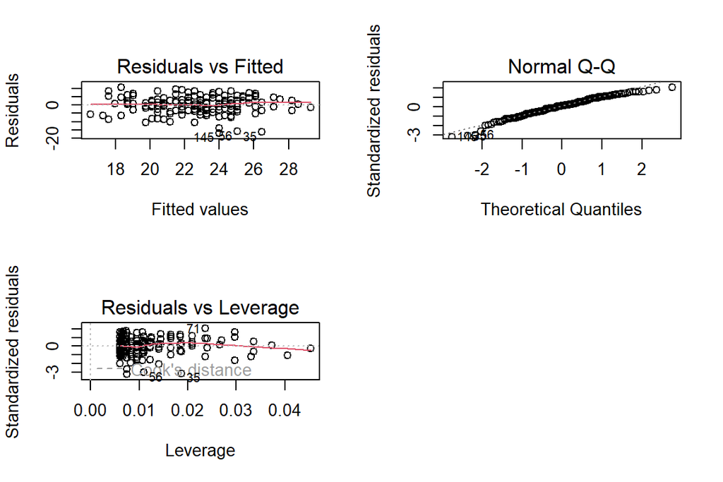

```r
par(mfrow = c(2,2))
plot(Model2, which = c(1,2,5))
```

Residuals vs Fitted values: This is used to check the linearity assumption. A horizontal line, without distinct patterns is an indication for a good linearity. In this model (Model2), there is no any pattern in the residual plot. So, the linearity assumption has met here.

Normal QQ-plot: This is used to examine whether the residuals are normally distributed. It’s good if residuals points follow the straight dashed line. In Model2, almost all the points fall approximately along the reference line, indicating the normality. So, the normality assumption has met here.

Residuals vs Leverage: This is used to identify influential cases, that is extreme values that might influence the regression results when included or excluded from the analysis. The plot created using Model2 highlights the top 3 most extreme points as #35, #56 and #71. Even though the extreme point:#71 has not exceeded 3 standard deviations, the extreme points #35 and #56 have exceeded it (or else they have standardized residuals below -3).  
As there are influential cases in Model2, the assumption is not met.

# Logistic Regression

```r
date()
```

```
## [1] "Fri Nov 18 23:00:03 2022"
```

## Read the data

```r
alc <- read.table("https://raw.githubusercontent.com/KimmoVehkalahti/Helsinki-Open-Data-Science/master/datasets/alc.csv", sep=",", header=TRUE)

dim(alc)
```

```
## [1] 370  35
```

```r
str(alc)
```

```
## 'data.frame':    370 obs. of  35 variables:
##  $ school    : chr  "GP" "GP" "GP" "GP" ...
##  $ sex       : chr  "F" "F" "F" "F" ...
##  $ age       : int  18 17 15 15 16 16 16 17 15 15 ...
##  $ address   : chr  "U" "U" "U" "U" ...
##  $ famsize   : chr  "GT3" "GT3" "LE3" "GT3" ...
##  $ Pstatus   : chr  "A" "T" "T" "T" ...
##  $ Medu      : int  4 1 1 4 3 4 2 4 3 3 ...
##  $ Fedu      : int  4 1 1 2 3 3 2 4 2 4 ...
##  $ Mjob      : chr  "at_home" "at_home" "at_home" "health" ...
##  $ Fjob      : chr  "teacher" "other" "other" "services" ...
##  $ reason    : chr  "course" "course" "other" "home" ...
##  $ guardian  : chr  "mother" "father" "mother" "mother" ...
##  $ traveltime: int  2 1 1 1 1 1 1 2 1 1 ...
##  $ studytime : int  2 2 2 3 2 2 2 2 2 2 ...
```

[output cut: 21 more lines]

```r
colnames(alc)
```

```
##  [1] "school"     "sex"        "age"        "address"    "famsize"
##  [6] "Pstatus"    "Medu"       "Fedu"       "Mjob"       "Fjob"
## [11] "reason"     "guardian"   "traveltime" "studytime"  "schoolsup"
## [16] "famsup"     "activities" "nursery"    "higher"     "internet"
## [21] "romantic"   "famrel"     "freetime"   "goout"      "Dalc"
## [26] "Walc"       "health"     "failures"   "paid"       "absences"
## [31] "G1"         "G2"         "G3"         "alc_use"    "high_use"
```

```r
View(alc)
```

Even though, I have successfully wrangled the dataset, I decided to go with Kimmo’s analyzed dataset for further analysis.

I gave the dataset a name as “alc”. In the further analysis, this dataset will be adressed by “alc”.

The data are from two identical questionnaires related to secondary school student alcohol consumption in Portugal. The data include student grades, demographic data, social and school related features. They were collected through school reports and questionnaires. For this analysis purpose, the data was retrieve from Student Performance Data Set of UCI Machine Learning Repository. Two datasets were provided regarding the performance in Mathematics (mat) and Portuguese language (por). Those datasets were wrangled and linked into one dataset for the further analyze purpose. There are 370 observations and 35 variables: school, sex, age, address, famsize, Pstatus, Medu, Fedu, Mjob, Fjob, reason, guardian, traveltime, studytime, schoolsup, famsup, activities, nursery, higher, internet, romantic, famrel, freetime, goout, Dalc, Walc, health, failures, paid, absences, G1, G2, G3, alc_use and high_use.

```r
library(tidyverse)
library(gapminder)
library(finalfit)
```

## Hypothesis

H1 : There is a relationship between high usage of alcohol and gender (Males may have high alcohol consumption)

H2 : There is a relationship between high usage of alcohol and romantic relationship (Those who are not in a relationship may have high alcohol consumption)

H3 : There is a relationship between high usage of alcohol and number of school absences (Those who have high school absences may have high alcohol consumption)

H4 : There is a relationship between high usage of alcohol and Final Grade (Those who have lower final grade may have high alcohol consumption)

## Numerical and Graphical Representation

```r
# Gender and Alcohol Usage

alc %>%
  group_by(sex, high_use) %>%
  tally() %>%
  spread(high_use, n)
```

```
## # A tibble: 2 × 3
## # Groups:   sex [2]
##   sex   `FALSE` `TRUE`
##   <chr>   <int>  <int>
## 1 F         154     41
## 2 M         105     70
```

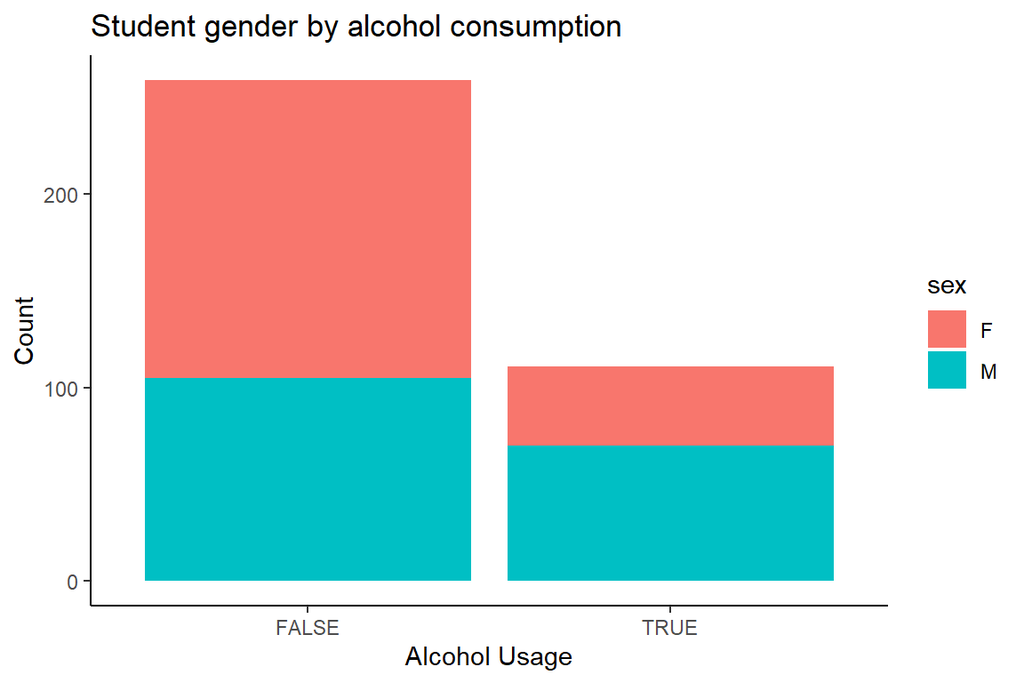

```r
g1 <- ggplot(alc, aes(high_use))
g1 + geom_bar(aes(fill = sex)) + ylab("Count") + xlab("Alcohol Usage") + ggtitle("Student gender by alcohol consumption") + theme_classic()
```

The majority of the people who consume high alcohol are males. The majority of the people who consume less alcohol are females.Looking at this, I think there may be a relationship between gender and the usage of alcohol, and males may have a higher consumption.

```r
# Romantic Relationship and Alcohol Usage

alc %>%
  group_by(romantic, high_use) %>%
  tally() %>%
  spread(high_use, n)
```

```
## # A tibble: 2 × 3
## # Groups:   romantic [2]
##   romantic `FALSE` `TRUE`
##   <chr>      <int>  <int>
## 1 no           173     78
## 2 yes           86     33
```

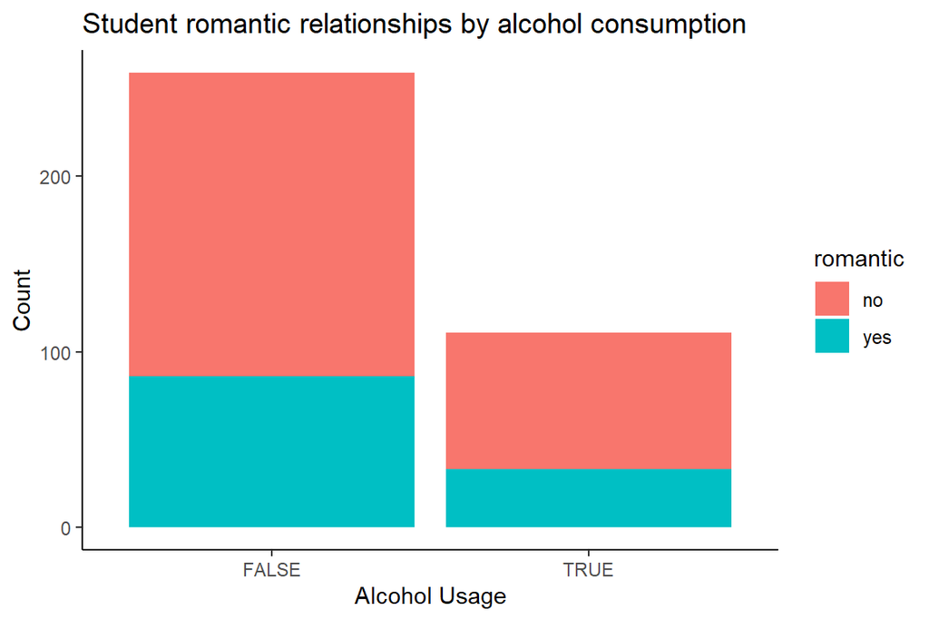

```r
g2 <- ggplot(alc, aes(high_use))
g2 + geom_bar(aes(fill = romantic)) + ylab("Count") + xlab("Alcohol Usage") + ggtitle("Student romantic relationships by alcohol consumption") + theme_classic()
```

The majority of the people who consume high alcohol are those who are not a romantic relationship. Similarly, the majority of the people who consume less alcohol also are those who are not a romantic relationship. Looking at this, there may be no any relationship between romantic relationship and the usage of alcohol.

```r
# Number of School Absences and Alcohol Usage

alc %>%
  group_by(high_use) %>%
  summarise(mean_absences = mean(absences))
```

```
## # A tibble: 2 × 2
##   high_use mean_absences
##   <lgl>            <dbl>
## 1 FALSE             3.71
## 2 TRUE              6.38
```

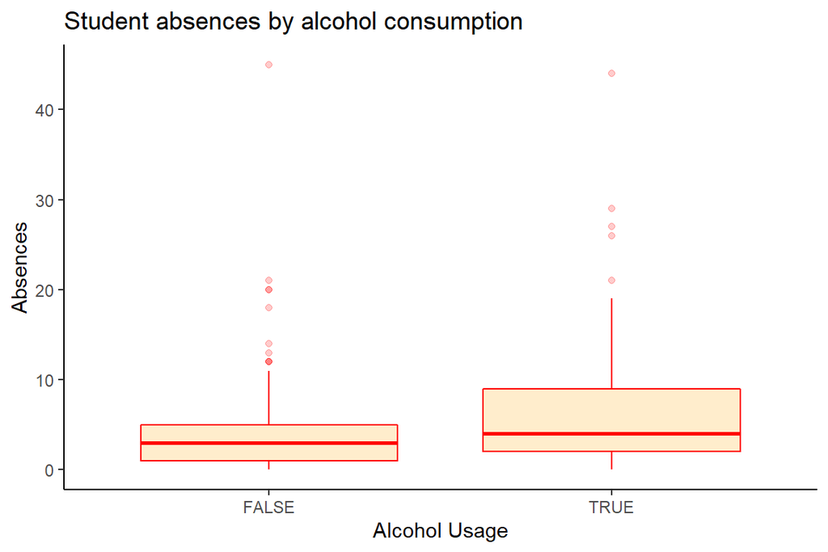

```r
g3 <- ggplot(alc, aes(x = high_use, y = absences))
g3 + geom_boxplot(color="red", fill="orange", alpha=0.2) + ylab("Absences") + xlab("Alcohol Usage") + ggtitle("Student absences by alcohol consumption") + theme_classic()
```

Compared to those who consume less alcohol, the ones who consume high alcohol tend to get more absences from their school. Thus, I think there may be a relationship between alcohol usage and the number of school absences, and those who get more absence may have high consumption of alcohol.

```r
# Number of School Absences and Alcohol Usage

alc %>%
  group_by(high_use) %>%
  summarise(mean_absences = mean(G3))
```

```
## # A tibble: 2 × 2
##   high_use mean_absences
##   <lgl>            <dbl>
## 1 FALSE             11.8
## 2 TRUE              10.9
```

[figure not shown]

```r
g4 <- ggplot(alc, aes(x = high_use, y = G3))
g4 + geom_boxplot(color="darkblue", fill="blue", alpha=0.2) + ylab("Final Grade") + xlab("Alcohol Usage") + ggtitle("Student absences by alcohol consumption") + theme_classic()
```

Compared to those who consume less alcohol, the ones who consume high alcohol tend to get less results for their final exam. Thus, I think there may be a relationship between alcohol usage and the final grade of students, and those who score less grades may have high consumption of alcohol.

## Model Fitting and Interpretation

```r
Model <- glm(high_use ~ sex + romantic + absences + G3, data = alc, family = "binomial")

summary(Model)
```

```
##
## Call:
## glm(formula = high_use ~ sex + romantic + absences + G3, family = "binomial",
##     data = alc)
##
## Deviance Residuals:
##     Min       1Q   Median       3Q      Max
## -2.1950  -0.8506  -0.6125   1.0695   2.1557
##
## Coefficients:
##             Estimate Std. Error z value Pr(>|z|)
## (Intercept) -0.80786    0.48828  -1.654   0.0980 .
## sexM         1.02891    0.24635   4.177 2.96e-05 ***
## romanticyes -0.27725    0.26621  -1.041   0.2977
## absences     0.09402    0.02332   4.032 5.54e-05 ***
## G3          -0.08309    0.03702  -2.244   0.0248 *
## ---
## Signif. codes:  0 '***' 0.001 '**' 0.01 '*' 0.05 '.' 0.1 ' ' 1
##
## (Dispersion parameter for binomial family taken to be 1)
##
##     Null deviance: 452.04  on 369  degrees of freedom
## Residual deviance: 409.87  on 365  degrees of freedom
## AIC: 419.87
##
## Number of Fisher Scoring iterations: 4
```

```r
OR <- coef(Model) %>% exp

CI <- confint(Model) %>% exp
cbind(OR, CI)
```

```
##                    OR     2.5 %    97.5 %
## (Intercept) 0.4458116 0.1689959 1.1530093
## sexM        2.7980165 1.7371345 4.5719807
## romanticyes 0.7578671 0.4453847 1.2680721
## absences    1.0985786 1.0517733 1.1526939
## G3          0.9202643 0.8550404 0.9891028
```

Except for the romantic relationships (variable: romantic), all the other variables: gender (sex), number of school absences (absences) and final grade (G3) are significant factors to the usage of alcohol.

Regarding the coefficients of the model,

Sex: After adjusting for all the confounders, the odd ratio of male is exp(1.02891) = 2.7980165, with 95% Confidence Interval being 1.7371345 to 4.5719807. This means that the odds of usage of alcohol for males are 179% more likely as compared to females.

Romantic: This appeared to be an insignificant variable to the model.

Absences: After adjusting for all the confounders, the odd ratio of absences is exp(0.09402) = 1.0985786, with 95% Confidence Interval being 1.0517733 to 1.1526939. This means that the odds of usage of alcohol increases by about 9% for every 1 unit increase in the number of absences.

Earlier I thought that all the selected variable would have a significant relationship with the usage of alcohol. But it was proven that the romantic relationship is an insignificant factor to the alcohol usage. However all the other variables were significant, similar to what I thought before.

## Predictive power of the model

### Computation of Predictions

```r
ModelN <- glm(high_use ~ sex + absences + G3, data = alc, family = "binomial")

probabilities <- predict(ModelN, type = "response")

library(dplyr)

alc <- mutate(alc, probability = probabilities)

alc <- mutate(alc, prediction = probability > 0.5)

select(alc, G3, absences, sex, high_use, probability, prediction) %>% tail(10)
```

```
##     G3 absences sex high_use probability prediction
## 361 13        3   M    FALSE   0.3438727      FALSE
## 362  0        0   M    FALSE   0.5253210       TRUE
## 363  2        7   M     TRUE   0.6434944       TRUE
## 364 12        1   F    FALSE   0.1422811      FALSE
## 365  8        6   F    FALSE   0.2651901      FALSE
## 366  5        2   F    FALSE   0.2400651      FALSE
## 367 12        2   F    FALSE   0.1539348      FALSE
## 368  4        3   F    FALSE   0.2726742      FALSE
## 369 13        4   M     TRUE   0.3650114      FALSE
## 370 10        2   M     TRUE   0.3770647      FALSE
```

```r
table(high_use = alc$high_use, prediction = alc$prediction)
```

```
##         prediction
## high_use FALSE TRUE
##    FALSE   248   11
##    TRUE     83   28
```

In order to find the predictive power of the model, the insignificant variable: romantic relationship was removed from the model. A total of 276 cases was correctly predicted by the model. However, a total of 94 cases was incorrectly predicted by the model. The model resulted in 248 true negatives, 28 true positives, 83 false negatives and 11 false positives.

### Visualization of predictions

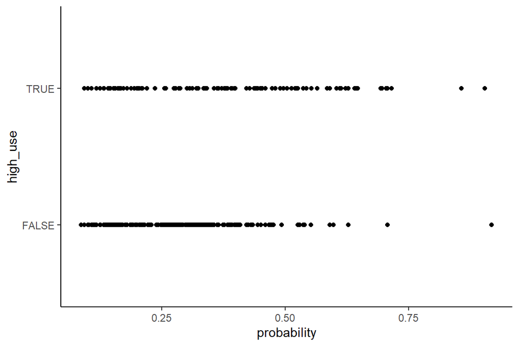

```r
library(dplyr); library(ggplot2)

g5 <- ggplot(alc, aes(x = probability, y = high_use))
g5 + geom_point() + theme_classic()
```

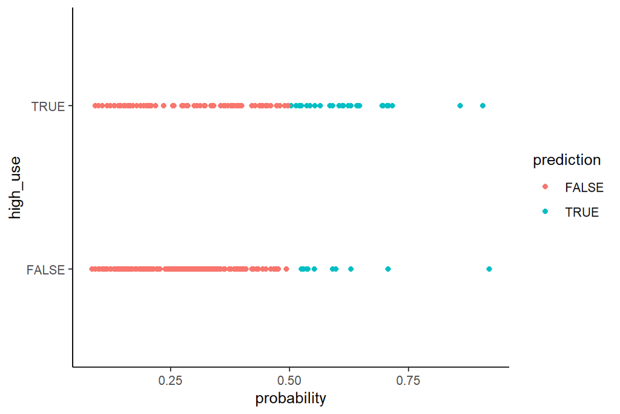

```r
g6 <- ggplot(alc, aes(x = probability, y = high_use, col = prediction))
g6 + geom_point() + theme_classic()
```

### Computation of probabilities and margins of predictions

```r
# Target variable versus the predictions
table(high_use = alc$high_use, prediction = alc$prediction)
```

```
##         prediction
## high_use FALSE TRUE
##    FALSE   248   11
##    TRUE     83   28
```

```r
# Target variable versus the probabilities of predictions
table(high_use = alc$high_use, prediction = alc$prediction) %>% prop.table()
```

```
##         prediction
## high_use      FALSE       TRUE
##    FALSE 0.67027027 0.02972973
##    TRUE  0.22432432 0.07567568
```

```r
#Add all margin totals
table(high_use = alc$high_use, prediction = alc$prediction) %>% prop.table() %>% addmargins()
```

```
##         prediction
## high_use      FALSE       TRUE        Sum
##    FALSE 0.67027027 0.02972973 0.70000000
##    TRUE  0.22432432 0.07567568 0.30000000
##    Sum   0.89459459 0.10540541 1.00000000
```

67% of the false high alcohol usage were correctly predicted while 3% of false high alcohol usage were incorrectly predicted as true. On the other hand, only 8% of the true high alcohol usage were correctly predicted while 22% of true high alcohol usage were incorrectly predicted as false.

### Accuracy and loss functions

```r
# define a loss function (mean prediction error)
loss_func <- function(class, prob) {
  n_wrong <- abs(class - prob) > 0.5
  mean(n_wrong)
}

# call loss_func to compute the average number of wrong predictions in the (training) data
loss_func(class = alc$high_use, prob = 0)
```

```
## [1] 0.3
```

```r
loss_func(class = alc$high_use, prob = 1)
```

```
## [1] 0.7
```

```r
loss_func(class = alc$high_use, prob = alc$probability)
```

```
## [1] 0.2540541
```

Total proportion of inaccurately classified individuals or the training error of this model is 25%. Only a one fourth of the cases were inaccurately classified, while three fourth of them were accurately classified. Overall, the performance of this model is good enough for further purposes.